# 202305 Midterm 2

## Instructions:

### 1.Show both commands and outputs unless specified otherwise.

### 2.For visualization, always use ggplot() commands, unless specified otherwise.

### Question 1: Download the file people.csv from Brightspace. Import the file and save it as a data frame named “features”.

1. Which variables are categorical, which ones are numerical?
2. Produce a bar graph showing the distribution of hair colours with the following:

   Different colour for different bars

   A title.

   A x-axis label.
3. Produce a side-by-side boxplot of weight by gender with y-axis label “Weight in kg”.

```r
#set working directory first
library(tidyverse)
features <- read_csv('people.csv')
head(features)
```

| hair | eye | gender | height | weight |
| --- | --- | --- | --- | --- |
| Black | Brown | Male | 177.7 | 85.0 |
| Black | Brown | Male | 175.2 | 94.5 |
| Black | Brown | Male | 190.9 | 97.0 |
| Black | Brown | Male | 178.0 | 95.3 |
| Black | Brown | Male | 170.9 | 77.9 |
| Black | Brown | Male | 159.6 | 80.6 |

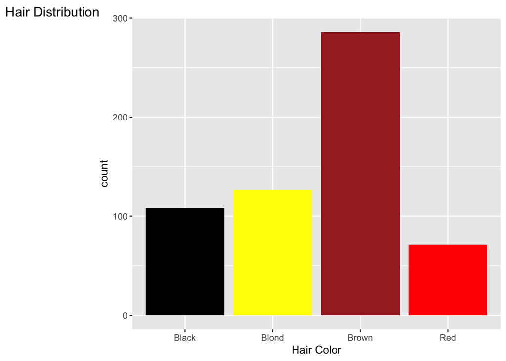

```r
# (a) Answer below:
#hair col is categorical
#eye col is categorical
#gender col is categorical
#height col is numerical
#weight col is numerical

# (b) Answer below:
#Produce a bar graph showing the distribution of hair colours with the following:

 #  Different colour for different bars

  # A title.

   #A x-axis label.

ggplot(data = features, aes(x = hair)) +
  geom_bar(fill=c('Black', 'Yellow', 'Brown', 'Red')) +
  labs(tag = 'Hair Distribution') +
  xlab('Hair Color')
```

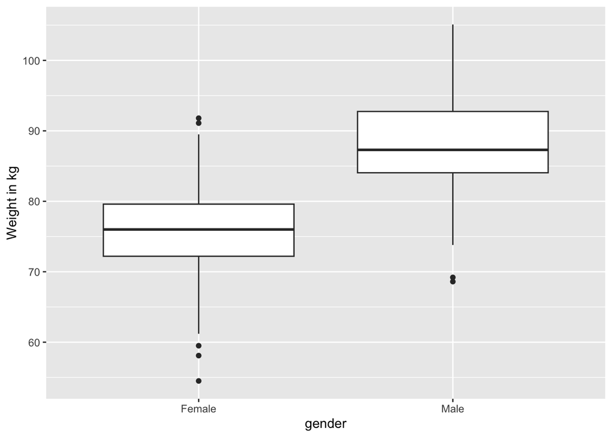

```r
# (c) Answer below:
  #c. Produce a side-by-side boxplot of weight by gender with y-axis label "Weight in kg".

 ggplot(features, aes(x = gender, y = weight)) +
   geom_boxplot() +
   ylab("Weight in kg")
```

### Question 2 Use the “features” data frame.

1. Compute and display the total number of people with “Hazel” eyes.
2. Compute and display the sample proportion of people with Hazel eyes.

```r
#a
head(features)
```

| hair | eye | gender | height | weight |
| --- | --- | --- | --- | --- |
| Black | Brown | Male | 177.7 | 85.0 |
| Black | Brown | Male | 175.2 | 94.5 |
| Black | Brown | Male | 190.9 | 97.0 |
| Black | Brown | Male | 178.0 | 95.3 |
| Black | Brown | Male | 170.9 | 77.9 |
| Black | Brown | Male | 159.6 | 80.6 |

```r
hazel_count<-0
for(color in features$eye) {
  if(color == 'Hazel') {
    hazel_count <- hazel_count + 1
  }
}
hazel_count
```

```
## [1] 93
```

```r
#b
sample_proportion <- hazel_count / length(features$eye)
sample_proportion
```

```
## [1] 0.1570946
```

### Question 3: Use the features data frame for the following:

1. Bootstrap 5000 sample variances of height. Save your bootstrapped variances to a vector called boot_var.
2. Give an estimate for the variance of height from the bootstrapped sample.
3. Compute a 95% bootstrapped confidence interval for the true value of the variance of height.

```r
# (a) Answer below:
boot_var <- numeric(5000)
for (i in 1:5000) {
    resampled_data <- sample(features$height, replace = TRUE)
    boot_var[i] <- var(resampled_data)
}
boot_var
```

[output not shown]

[output cut: 610 more lines]

```r
# (b) Answer below:
var(boot_var)
```

```
## [1] 21.68312
```

```r
# (c) Answer below:
lower_quantile <- quantile(boot_var, 0.05)
upper_quantile <- quantile(boot_var, 0.95)

bootstrapped_confidence_interval <- c(lower_quantile, upper_quantile)
bootstrapped_confidence_interval
```

```
##       5%      95%
## 73.79924 89.12704
```

### Question 4: Use the features data frame and perform the following:

1. Create a data frame named “male.features” that contains information only for male. There should be 279 observations in this new data frame. Show the first six observations of male.features.

For part b to e, use the data frame “male.features”. If you don’t know how to do part a, then use the features data frame. Some mark will be deducted.

2. Produce a ggplot histogram of weight with the following:

   blue border

   green bar

   (no title needed)
3. Write a command to take a sample of 144 weights without replacement and named this vector x. Do not display the vector x.
4. Compute the mean, standard deviation, estimated standard error for the sample and save them as some variable names of your choice.
5. Compute a 84% confidence interval for male weight.

```r
library(dplyr)
#a

#Create a data frame named "male.features" that contains information only for
 #  male. There should be 279 observations in this new data frame. Show the first
  # six observations of male.features.

#For part b to e, use the data frame "male.features". If you don't know how to do
#part a, then use the features data frame. Some mark will be deducted.


filtered <- features %>%
  filter(gender == 'Male')%>%
  group_by(gender)


male.features <- data.frame(filtered)
male.features[1:6,]
```

|  | hair | eye | gender | height | weight |
| --- | --- | --- | --- | --- | --- |
| 1 | Black | Brown | Male | 177.7 | 85.0 |
| 2 | Black | Brown | Male | 175.2 | 94.5 |
| 3 | Black | Brown | Male | 190.9 | 97.0 |
| 4 | Black | Brown | Male | 178.0 | 95.3 |
| 5 | Black | Brown | Male | 170.9 | 77.9 |
| 6 | Black | Brown | Male | 159.6 | 80.6 |

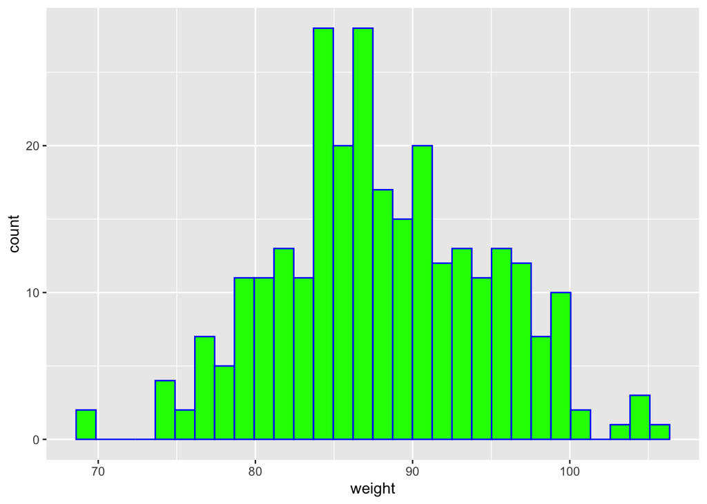

```r
#b
ggplot(male.features, aes(x = weight)) +
  geom_histogram(color = 'blue', fill = 'green')
```

```r
#c
#set.seed(12345)
#x <- sample(male.features$weights, size = 144, replace = FALSE)
#x



#d
#Compute the mean, standard deviation, estimated standard error for the sample and save them as #some variable names of your choice.

mean <- mean(male.features)
mean_sd <- sd(mean)
#standard_error <- sd(male.features)

mean_sd
```

```
## [1] NA
```

```r
#standard_error




#e

mean_weight <- mean(male.features$weight)


lower_quantile <- quantile(male.features$weight, 0.016)
upper_quantile <- quantile(male.features$weight, 0.84)

confidence_interval <- c(lower_quantile, upper_quantile)
confidence_interval
```

```
##    1.6%     84%
## 74.5792 95.3000
```

### Question 5: Use the “male.features” data frame again.

1. Produce a scatterplot of height versus weight. Set the x-axis to be height.
2. Describe the direction and form of the relationship.
3. Compute the correlation between the two variables and describe what this implies for the linearity and strength of the relationship.

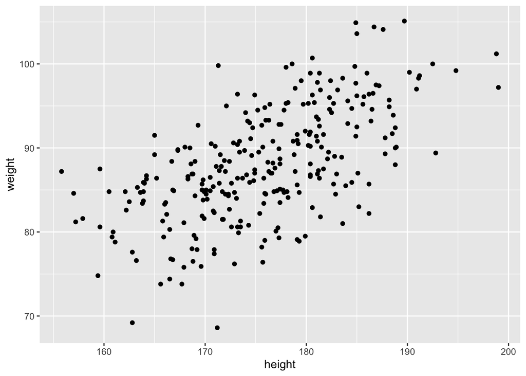

```r
# (a) Answer below:
ggplot(male.features, aes(x = height, y = weight)) +
  geom_point()
```

```r
# (b) Answer below:


# (c) Answer below:
args(cor)
```

```
## function (x, y = NULL, use = "everything", method = c("pearson",
##     "kendall", "spearman"))
## NULL
```

```r
cor(x = male.features$height, y = male.features$weight)
```

```
## [1] 0.6120493
```

### When you’re finished or when time is up, knit the Rmarkdown to a html file and submit it to the Midterm 2 folder.Comment out (don’t delete) the commands that don’t run and submit the output.To be safe, you can also submit the rmd file together with the html file.